| title: “FlexCoDE: the Flexible Conditional Density Estimator” |
| --- |
| author: “Rafael Izbicki” |
| date: “2016-01-28” |
| output: |
| html_document: |
| toc: true |
| number_sections: true |
| vignette: > |
| % |
| % |
| % |

# Introduction

FlexCode is a flexible approach to conditional density estimation. We observed an idd sample $(\mathbf{x}_1,z_1),\ldots,(\mathbf{x}_n,z_n)$ and we wish to estimate $f(z|\mathbf{x})$, the density of $z \in \mathbb{R}$ given $\mathbf{x} \in \mathbb{R}^d$. The estimator is based on a basis expansion of the conditional density, where each of the expansion coefficients is estimated via a regression method. FlexCode is flexible in that it is open for one to use his favorite regression method. In particular, it adapts to several situations (e.g., sparsity, redundancy of covariate, mixed covariates types, functional covariates etc) if the right regression method is chosen.

The FlexCode package currently implements several regression methods:

- Sparse Additive Regression (SpAM) (*regressionFunction.SpAM*)
- Spectral Series Regression (*regressionFunction.Series*)
- Kernel Nearest Neighbors Regression (*regressionFunction.NN*)
- Nadaraya-Watson Regression (*regressionFunction.NW*)
- Random Forests (*regressionFunction.Forest*)

The user may also implement his own regression function.

The package also offers tools to combine (stack) various estimators and visualize them.

# Fitting Conditional Density Estimators

We illustrate the methodology using an artificial data set: for each sample, there are 10 observed covariates that are generated from a standard Gaussian distribution. The response is generated according to
$$Z_i = x_{i,1}+\epsilon_i,$$
with $\epsilon_i \sim N(0,0.1^2)$ iid, $i=1,\ldots,1000$, and $x_{i,1}$ is the first covariate. That is, the only covariate that affects the distribution of the response is the first one.

```r
library(FlexCoDE)
set.seed(400)
# generate data
n=1000
d=10
data=matrix(NA,n,d+1)
data[,1:d]=matrix(rnorm(n*d),n,d)
data[,d+1]=data[,1]+rnorm(n,0,0.1)
```

Now that we have our dataset, we can split it into training/validation and testing:

```r
# determine sample sizes
nTrain=round(0.7*n)
nValidation=round(0.25*n)
nTest=n-nTrain-nValidation

# split data
randomIndex=sample(1:n)
xTrain=data[randomIndex[1:nTrain],1:d]
xValidation=data[randomIndex[(nTrain+1):(nTrain+nValidation)],1:d]
xTest=data[randomIndex[(nTrain+nValidation+1):n],1:d]
zTrain=data[randomIndex[1:nTrain],d+1]
zValidation=data[randomIndex[(nTrain+1):(nTrain+nValidation)],d+1]
zTest=data[randomIndex[(nTrain+nValidation+1):n],d+1]
```

We can now fit our estimators. We start by fitting sparse additive models. This can be done via

```r
#library(FlexCoDE)
fit1=fitFlexCoDE(xTrain,zTrain,xValidation,zValidation,xTest,zTest,
                 regressionFunction = regressionFunction.SpAM,nIMax=50,
                 verbose=FALSE)
```

```r
print(fit1)
```

```
## FlexCoDE - Flexible Conditional Density Estimator
##
##
## ####### Caracteristic of the fitted CDE:
##
## Regression Method Used: SpAM
## Best Number of Expansion Coefficients Sected: 30
## Basis used: Fourier
## Estimated risk on test set: -4.1645451066084 (se: 0.731419185817491)
##
## ####### Caracteristic of the fitted regression:
##
## Number of splines chosen for each fitted regression: 1, 6, 11, 14, 6, 11, 14, 14, 9, 9, 14, 14, 11, 14, 14, 14, 14, 14, 14, 14, 14, 14, 14, 14, 14, 14, 14, 14, 14, 14
##
## How many times each covariate was selected:
##    covariate frequency
## 1          1 0.9666667
## 2          7 0.4333333
## 3         10 0.4333333
## 4          5 0.4000000
## 5          9 0.4000000
## 6          6 0.3666667
## 7          4 0.3333333
## 8          2 0.2666667
## 9          8 0.2333333
## 10         3 0.2000000
```

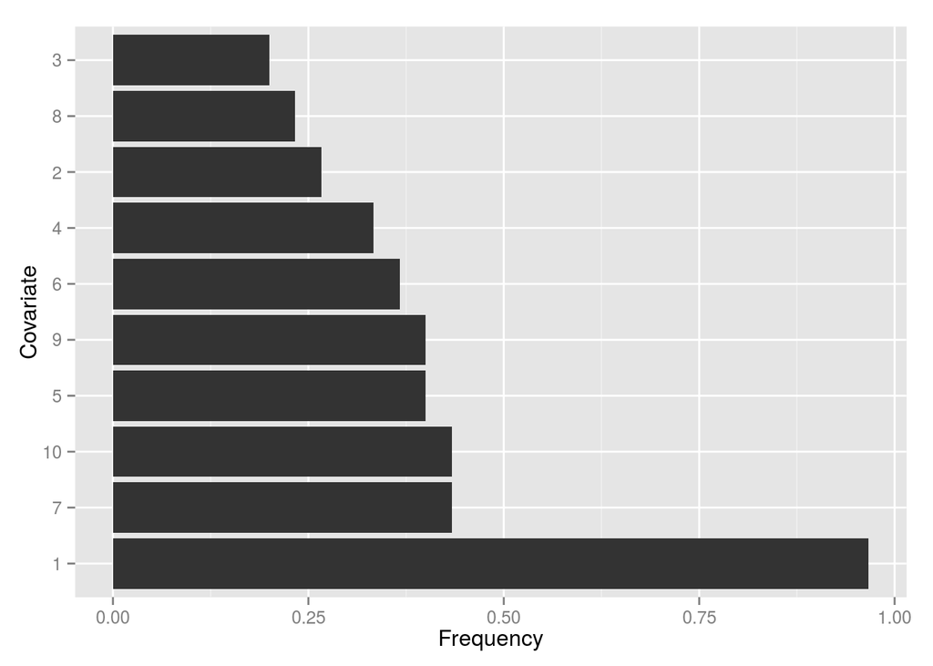

Notice the print function also provides a measure of importante of each covariate for some regression methods. In the case of SpAM, it shows how many of the fitted regressions selected each of the covariates. In this case, it is possible to see that the first covariate is the most important one. In fact, it is the only one that indeed influences the distribution of the response.

We can also plot some examples of estimated densities on new (testing) data. If we use the argument |predictionBandProb|, a second plot with the highest predictive regions (HPG) is also shown:

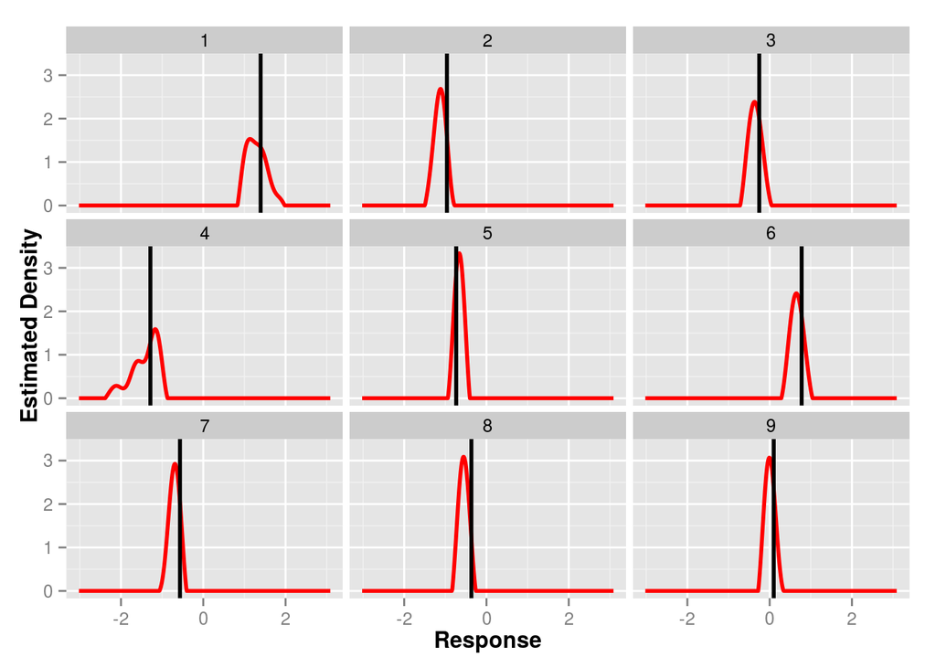

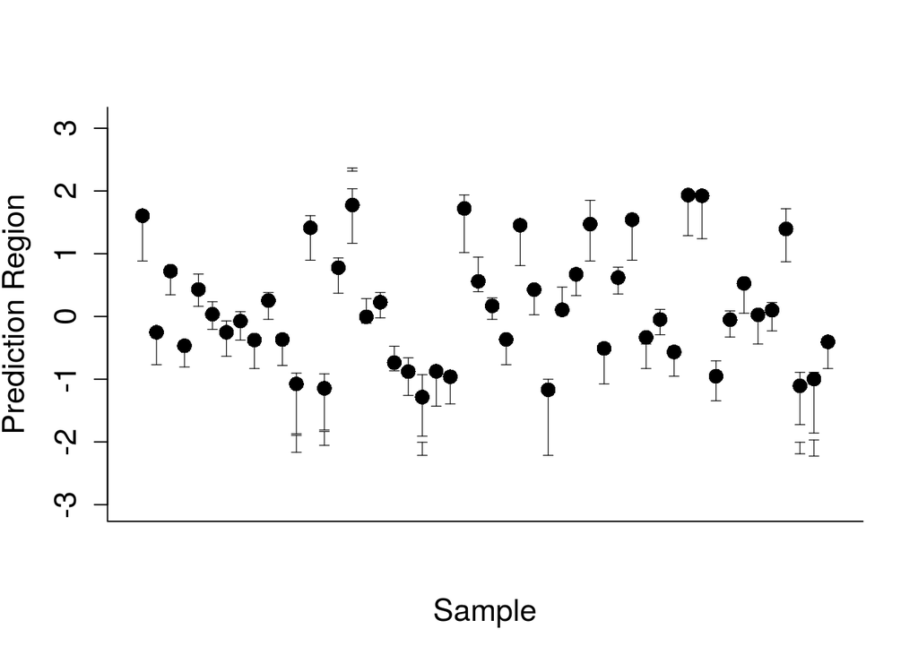

```r
plot(fit1,xTest,zTest,predictionBandProb=0.95)
```

## Parallel Computing

Some regression estimators can make use of parallel computing. For example, you can fit sparse additive model using 4 cores via

```r
fit1=fitFlexCoDE(xTrain,zTrain,xValidation,zValidation,xTest,zTest,
                 regressionFunction = regressionFunction.SpAM,
                 regressionFunction.extra=list(nCores=4),
                 verbose=FALSE)
```

This will typically take less time than using a naive calculation.

# Comparing Conditional Density Estimators

The package provides a nice way to compare conditional estimators estimated by FlexCode via different regression methods. This can be done by binding the various estimators. For instance, let’s fit two additional estimators:

```r
# random Forest
fit2=fitFlexCoDE(xTrain,zTrain,xValidation,zValidation,xTest,zTest,
                 regressionFunction = regressionFunction.Forest,
                 regressionFunction.extra=list(nCores=4),nIMax = 50,
                 verbose=FALSE)
# Nearest Neighbors estimator
fit3=fitFlexCoDE(xTrain,zTrain,xValidation,zValidation,xTest,zTest,
                 regressionFunction = regressionFunction.NN,
                 regressionFunction.extra=list(nCores=4),
                 verbose=FALSE)
```

You can bind the three estimators using

```r
fitBind=bindFlexCoDE(fit1,fit2,fit3)
```

You can now compare easily these estimators:

```r
print(fitBind)
```

```
## [[1]]
## FlexCoDE - Flexible Conditional Density Estimator
##
##
## ####### Caracteristic of the fitted CDE:
##
## Regression Method Used: SpAM
## Best Number of Expansion Coefficients Sected: 30
## Basis used: Fourier
## Estimated risk on test set: -4.1645451066084 (se: 0.731419185817491)
##
## ####### Caracteristic of the fitted regression:
##
## Number of splines chosen for each fitted regression: 1, 6, 11, 14, 6, 11, 14, 14, 9, 9, 14, 14, 11, 14, 14, 14, 14, 14, 14, 14, 14, 14, 14, 14, 14, 14, 14, 14, 14, 14
##
## How many times each covariate was selected:
##    covariate frequency
## 1          1 0.9666667
## 2          7 0.4333333
## 3         10 0.4333333
## 4          5 0.4000000
## 5          9 0.4000000
## 6          6 0.3666667
## 7          4 0.3333333
## 8          2 0.2666667
## 9          8 0.2333333
## 10         3 0.2000000
##
## [[2]]
## FlexCoDE - Flexible Conditional Density Estimator
##
##
## ####### Caracteristic of the fitted CDE:
##
## Regression Method Used: Forest
## Best Number of Expansion Coefficients Sected: 25
## Basis used: Fourier
## Estimated risk on test set: -6.66697801215973 (se: 0.475174062216526)
##
## ####### Caracteristic of the fitted regression:
```

[output cut: 16 more lines]

```
##
##
## ####### Caracteristic of the fitted CDE:
##
## Regression Method Used: NN
## Best Number of Expansion Coefficients Sected: 5
## Basis used: Fourier
## Estimated risk on test set: -1.60695788165786 (se: 0.0887959157234673)
##
## ####### Caracteristic of the fitted regression:
##
## Number of neighbors chosen for each fitted regression: 1, 6, 11, 16, 11
##
## attr(,"class")
## [1] "FlexCoDE_binded"
```

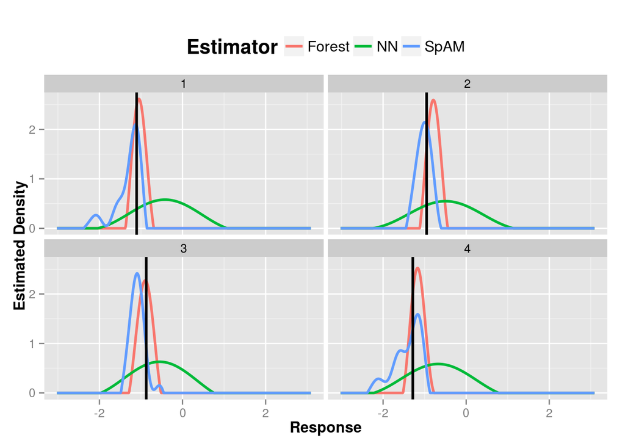

```r
plot(fitBind,xTest,zTest,nPlots = 4)
```

# Combining Conditional Density Estimators

```r
combinedEstimator=combineFlexCoDE(fitBind,xValidation,zValidation,xTest,zTest)
combinedEstimator$weights # best weights
```

```
## [1] 0.2385937 0.7614063 0.0000000
```

```r
combinedEstimator$estimatedRisk
```

```
## $mean
## [1] -6.521641
##
## $seBoot
## [1] 0.480252
```

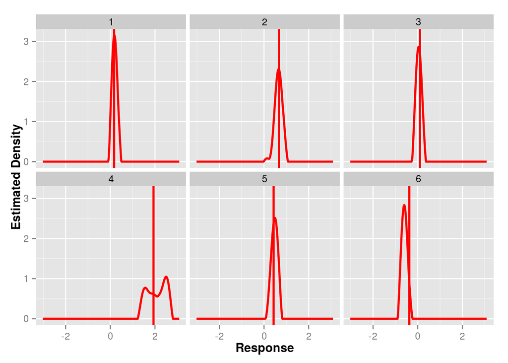

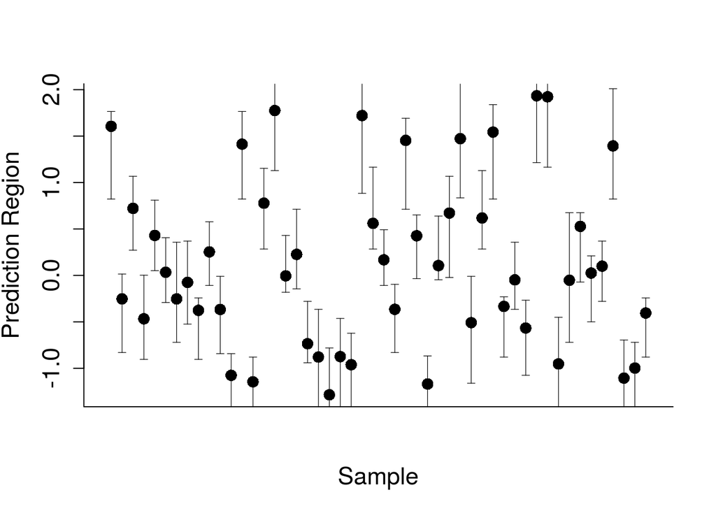

```r
plot(combinedEstimator,xTest,zTest,nPlots = 6,predictionBandProb = 0.95)
```

```r
print(combinedEstimator)
```

```
## Object of class combinedFlexCoDE containing 3 fitted FlexCoDE regression estimators with weights
##   0.2385937 0.7614063 0
##  respectively
##
##  Estimators use the following regression methods respectively:
## SpAM
## Forest
## NN
## Estimated risk on test set: -6.52164098530913 (se: 0.480251976122431)
##
##
##  ##############################
## ##############################
##
##
##  Regression fits are the following:
##
##  ##############################
##
##  Fit 1:
## FlexCoDE - Flexible Conditional Density Estimator
##
##
## ####### Caracteristic of the fitted CDE:
##
## Regression Method Used: SpAM
## Best Number of Expansion Coefficients Sected: 30
## Basis used: Fourier
## Estimated risk on test set: -4.1645451066084 (se: 0.731419185817491)
##
## ####### Caracteristic of the fitted regression:
##
## Number of splines chosen for each fitted regression: 1, 6, 11, 14, 6, 11, 14, 14, 9, 9, 14, 14, 11, 14, 14, 14, 14, 14, 14, 14, 14, 14, 14, 14, 14, 14, 14, 14, 14, 14
##
## How many times each covariate was selected:
##    covariate frequency
## 1          1 0.9666667
## 2          7 0.4333333
## 3         10 0.4333333
## 4          5 0.4000000
```

[output cut: 36 more lines]

```
##
##  Fit 3:
## FlexCoDE - Flexible Conditional Density Estimator
##
##
## ####### Caracteristic of the fitted CDE:
##
## Regression Method Used: NN
## Best Number of Expansion Coefficients Sected: 5
## Basis used: Fourier
## Estimated risk on test set: -1.60695788165786 (se: 0.0887959157234673)
##
## ####### Caracteristic of the fitted regression:
##
## Number of neighbors chosen for each fitted regression: 1, 6, 11, 16, 11
```

# Designing your own regression functions

You can design your own regression functions to estimate the conditional densities. In order to this, you need to write three functions:

1. regressionFunction.YourMethod: function that receives three arguments:
- x: matrix of covariates used to train the model
- responses: matrix where each row corresponds to a row in x and each column corresponds to a different response (in practice, it will be $\phi_i(z)$, but you do not need to worry about this)
- extra: a list with extra parameters used to fit your regression function you wish the used to have flexibility over Your function should output an object of the class *YourMethod* (the name you’ve assigned to the regressionFunction function). This object needs to have enough information for you to be able to predict the value of each of the regression functions on new data points $x$. We recommend you see the code of some existing regressionFunction methods to see how this can be done, for instance, regressionFunction.NN
2. predict.YourMethod: function that received three arguments:
- object: the output of regressionFunction.YourMethod, the regression function you’ve designed (an object of the class *YourMethod* - the name you’ve assigned to the regressionFunction function)
- xNew: matrix where each row is a new sample, and each column is a covariate
- maxTerms: how many regression functions should be predicted. That is, in regressionFunction.YourMethod, you’ve created say nIMax regression functions. In predict.YourMethod, you only need to predict the first maxTerms of these functions. The default of maxTerms should be NULL, and your function should make sure it is at most the number of regressions you’ve fitted via regressionFunction.YourMethod. The output of predict.YourMethod should be a matrix with the same number of rows as xNew and maxTerms column, where column j has the prediction of the j-th regression you’ve fitted in each of the samples from xNew. We recommend you see the code of some existing regressionFunction methods to see how this can be done, for instance, predict.NN
3. print.YourMethod: function that receives three arguments:
- regressionObject: the output of regressionFunction.YourMethod, the regression function you’ve designed (an object of the class *YourMethod* - the name you’ve assigned to the regressionFunction function)
- bestI: a number that indicates how many basis functions (regressions) will be used
- nameCovariates: name of the covariates Your function should then output your favorite statistics about the fitted regression functions. We recommend you see the code of some existing regressionFunction methods to see how this can be done, for instance, print.NN (which does not use nameCovariates)

# Kernelized version of the functions

An alternative way to use FlexCode is by using Gram matrices as inputs instead of the raw covariates. This allows for faster implementations when computing such matrices is time consuming (e.g., this computation can be performed outside R). It also yields flexibility, because the user can input his own kernel.

- Spectral Series Regression (*regressionFunction.SeriesKernel*)
- Kernel Nearest Neighbors Regression (*regressionFunction.NNKernel*)
- Support Distribution Regression (SDM) (*regressionFunction.SDMKernel*)

```r
n=1000
t=runif(n,0,2*pi)
d=50
vec=c(2/sqrt(d+3),1/sqrt(d+3)*rep(rep(c(-1,1),each=d/2)))[-(d+1)]
X=cos(t)%*%t(c(rep(1/sqrt(d-1),d-1),0))+sin(t)%*%t(vec)
z <- t+rnorm(n,0,0.5)
```

We not split the data into training/validation/testing:

```r
nTrain=700
nValidation=150
nTest=n-nValidation-nTrain
randomPerm=sample(1:n)


zTrain=z[randomPerm[1:nTrain]]
zValidation=z[randomPerm[(nTrain+1):(nTrain+nValidation)]]
zTest=z[randomPerm[(nTrain+nValidation+1):n]]
xTrain=X[randomPerm[1:nTrain],,drop=FALSE]
xValidation=X[randomPerm[(nTrain+1):(nTrain+nValidation)],,drop=FALSE]
xTest=X[randomPerm[(nTrain+nValidation+1):n],,drop=FALSE]
```

```r
eps=0.5 #
gramTrainTrain=exp((fields::rdist(xTrain,xTrain)^2)/eps)
gramValidationTrain=exp((fields::rdist(xValidation,xTrain)^2)/eps)
gramTestTrain=exp((fields::rdist(xTest,xTrain)^2)/eps)

fit=fitFlexCoDEKernel(gramTrainTrain,zTrain,gramValidationTrain,zValidation,gramTestTrain,zTest,regressionFunction = regressionFunction.SeriesKernel)
```

```
## [1] "Transforming Response"
## [1] "Fitting Regression Functions"
## [1] "Tuning Number of Expansion Coefficients (I)"
## [1] "Choosing optimal cutoff Delta"
##
##  Progress Bar:
## |        |
## ||       |
## |||      |
## ||||     |
## |||||    |
## ||||||   |
## |||||||  |
## |||||||| |
## ||||||||||
## [1] "Estimating risk on test set"
```

The same ploting/printing/predicting functions can be used with FlexCoDEKernel:

```
## [1] "Calculating predicted values"
## [1] "Creating plots"
```

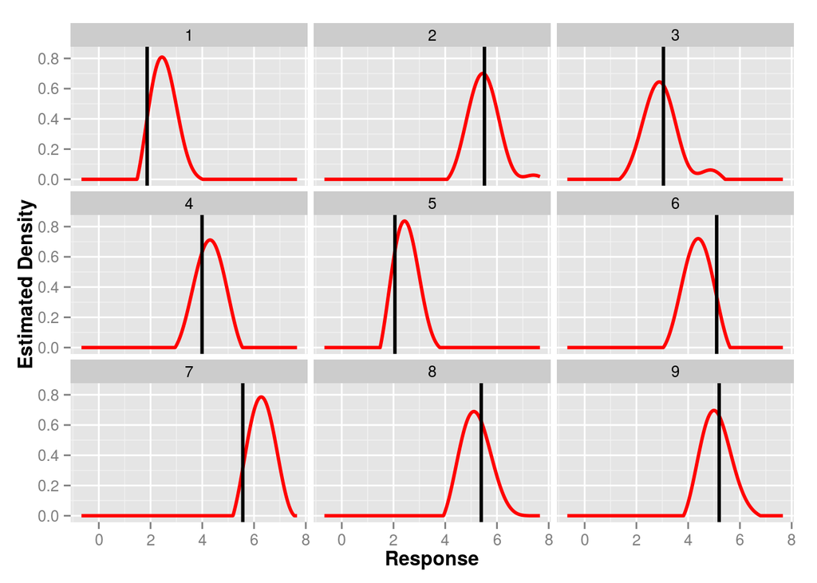

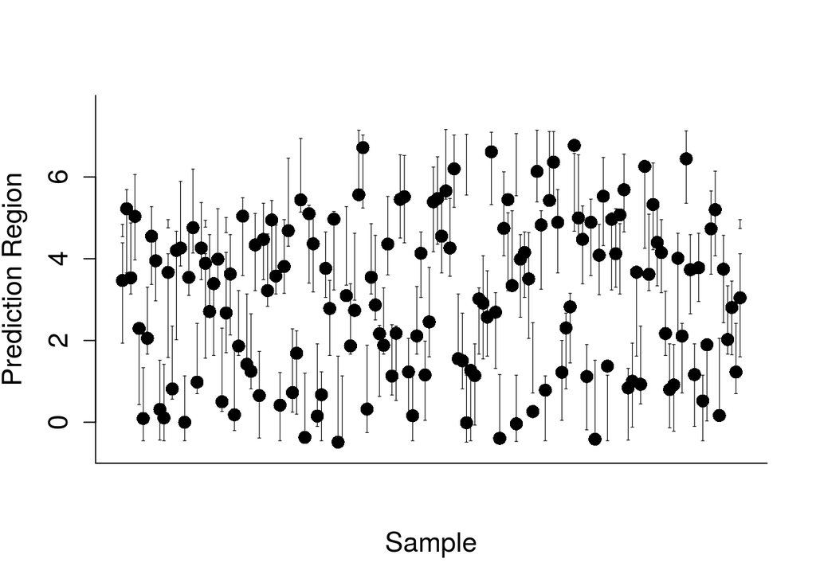

```r
plot(fit,gramTestTrain,zTest,predictionBandProb = 0.95)
```